# World Happiness Report from year 2005-2021

Kristen Blessman-Garcia

2023-04-27

## Introduction

The data is a CSV from kaggle based on the Gallup Poll/World Happiness Reports from 2005-2021.

## Background

I have practiced as an occupational therapy assistant for the past ten years and have an interest in the social/emotional well being of my clients. My domain focus for data science is psychology.

## Questions

- To understand global happiness trends and the factors contributing to well-being.
  - Which factors are related to an increased score on the happiness report?
  - Which countries were in the top ten most frequently?
  - Which countries had the lowest happiness score most frequently?

## World Happiness Report measured in Life.Ladder

Please imagine a ladder, with steps numbered from 10 at the top to 0 at the bottom.

## Ten

- The top of the ladder represents the best possible life for you.

## Zero

- The bottom of the ladder represents the worst possible life for you.

## What Libraries did you use?

- library(tidyverse) #Use to tidy and filter the data with dplyr
- library(ggplot2) #Use to draw plots
- library(countrycode) #Use to categorize countries by continent

## Look at the data

```
## Rows: 2,089
## Columns: 12
## $ Country.Name                      <chr> "Afghanistan", "Afghanistan", "Afgha…
## $ Year                              <int> 2008, 2009, 2010, 2011, 2012, 2013, …
## $ Life.Ladder                       <dbl> 3.723590, 4.401778, 4.758381, 3.8317…
## $ Log.GDP.per.capita                <dbl> 7.302574, 7.472446, 7.579183, 7.5520…
## $ Social.support                    <dbl> 0.4506623, 0.5523084, 0.5390752, 0.5…
## $ Healthy.life.expectancy.at.birth  <dbl> 50.500, 50.800, 51.100, 51.400, 51.7…
## $ Freedom.to.make.life.choices      <dbl> 0.7181143, 0.6788964, 0.6001272, 0.4…
## $ Generosity                        <dbl> 0.173169285, 0.195469126, 0.12585946…
## $ Perceptions.of.corruption         <dbl> 0.8816863, 0.8500354, 0.7067661, 0.7…
## $ Positive.affect                   <dbl> 0.4142970, 0.4814214, 0.5169067, 0.4…
## $ Negative.affect                   <dbl> 0.2581955, 0.2370924, 0.2753238, 0.2…
## $ Confidence.in.national.government <dbl> 0.6120721, 0.6115452, 0.2993574, 0.3…
```

## Data Key Terms and Categories

- GDP per capita- (variable name gdp) in purchasing power parity.
- Social support- “If you were in trouble, do you have relatives or friends you can count on to help you?”
- Freedom to make life choices- Are you satisfied or dissatisfied with your freedom to choose what you do with your life?”

## Missing Data

- Compared to the large dataset there was only a handful of missing values that were easily omitted.

```
##                      Country.Name                              Year
##                                 0                                 0
##                       Life.Ladder                Log.GDP.per.capita
##                                 0                                27
##                    Social.support  Healthy.life.expectancy.at.birth
##                                13                                58
##      Freedom.to.make.life.choices                        Generosity
##                                32                                80
##         Perceptions.of.corruption                   Positive.affect
##                               113                                24
##                   Negative.affect Confidence.in.national.government
##                                16                               216
```

- Due to limited time and multiple columns, I will not explore the columns of generosity, positive affect, and negative affect.

## Filter the data to year 2019 and find the max

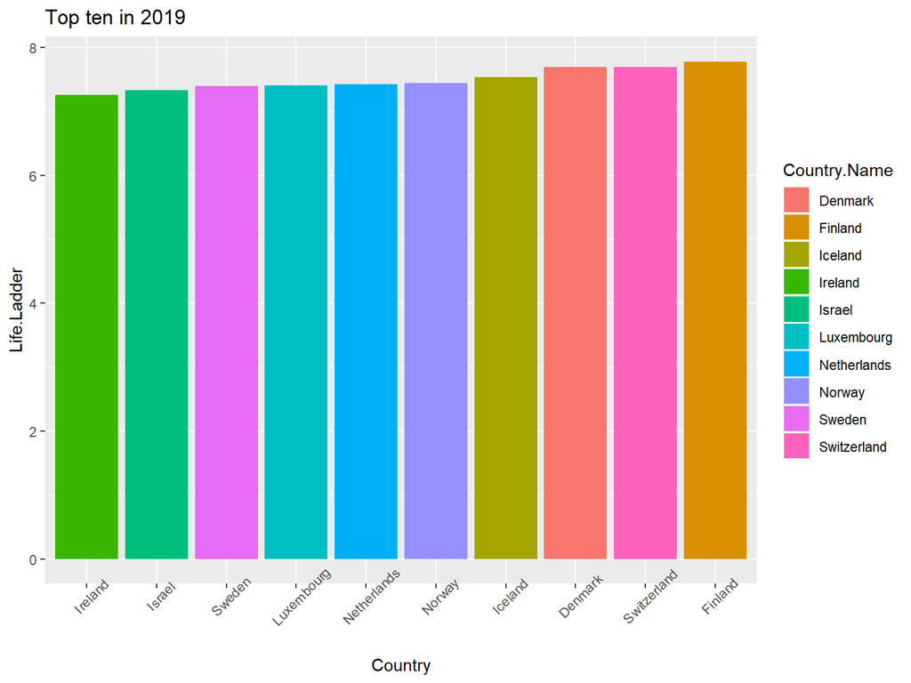

## Now find the minimum in 2019

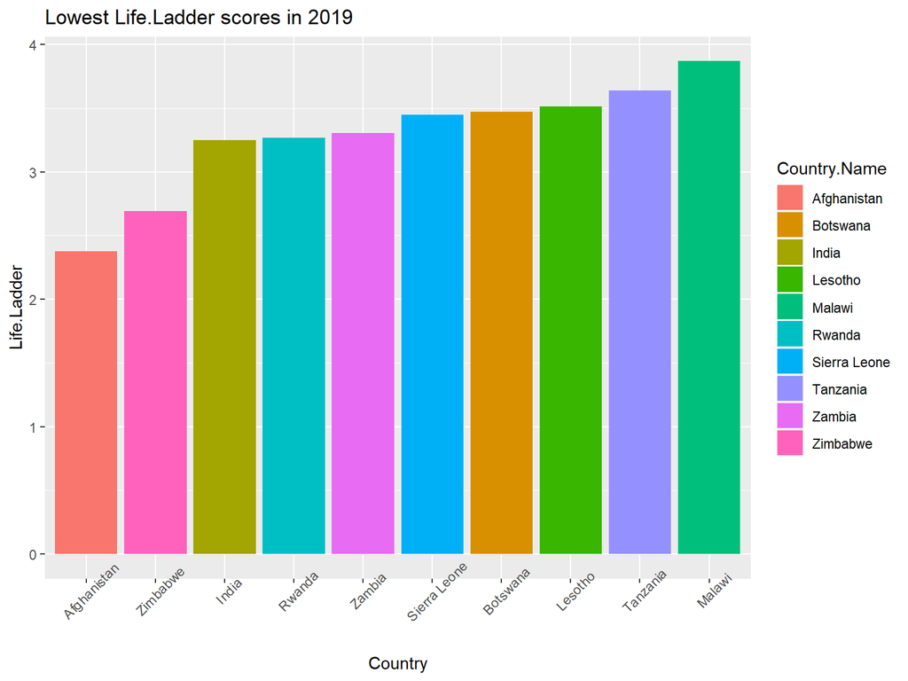

## The countries with the highest happiness scores most frequently

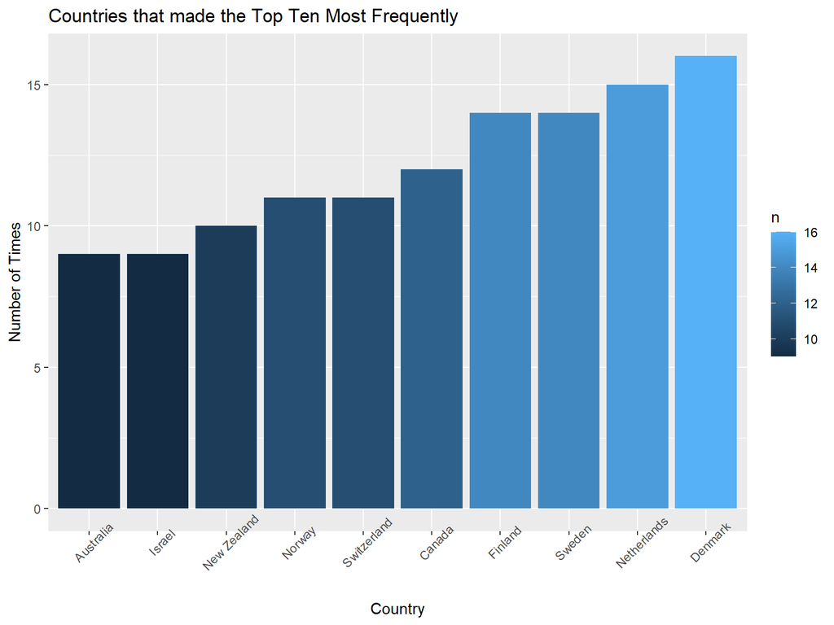

## This dataframe is looking at how many times the countries scored the lowest on Life. Ladder.

- It uses the count function.
- Then, on the next slide, we will take a look at the plot.

```
## # A tibble: 6 × 2
## # Groups:   Country.Name [6]
##   Country.Name                 n
##   <chr>                    <int>
## 1 Afghanistan                  4
## 2 Lebanon                      2
## 3 Central African Republic     1
## 4 Liberia                      1
## 5 Syria                        1
## 6 Zimbabwe                     1
```

## The countries with the lowest happiness scores most frequently

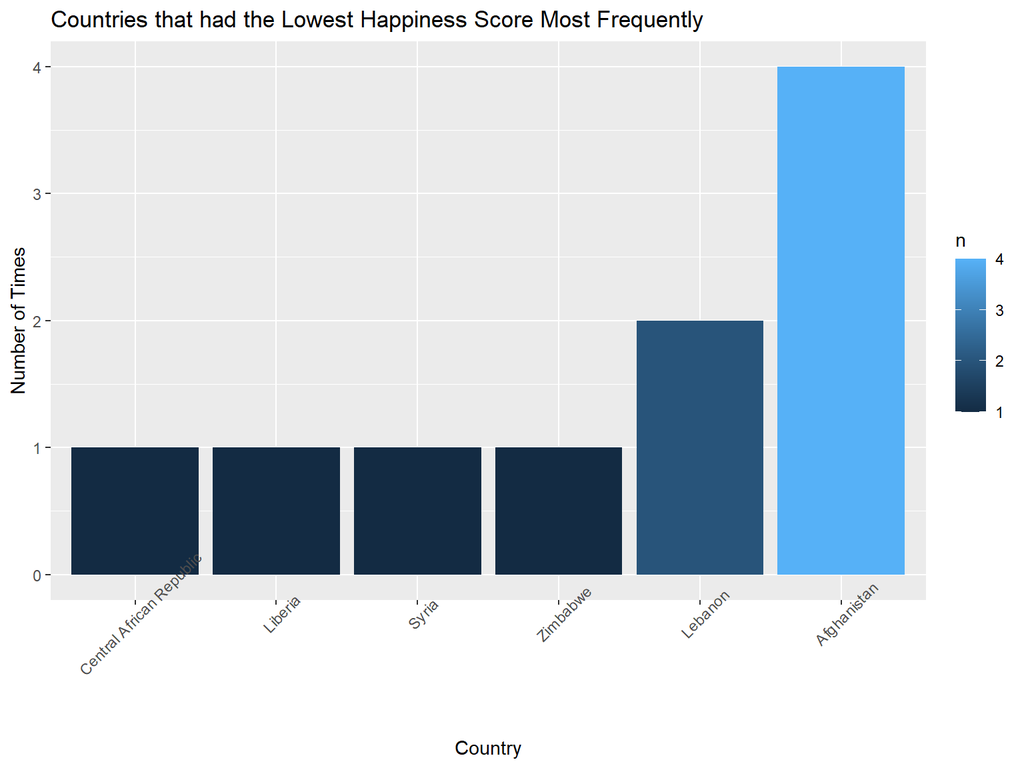

- Let’s see if there is a relationship between having confidence in the national government and overall well-being.

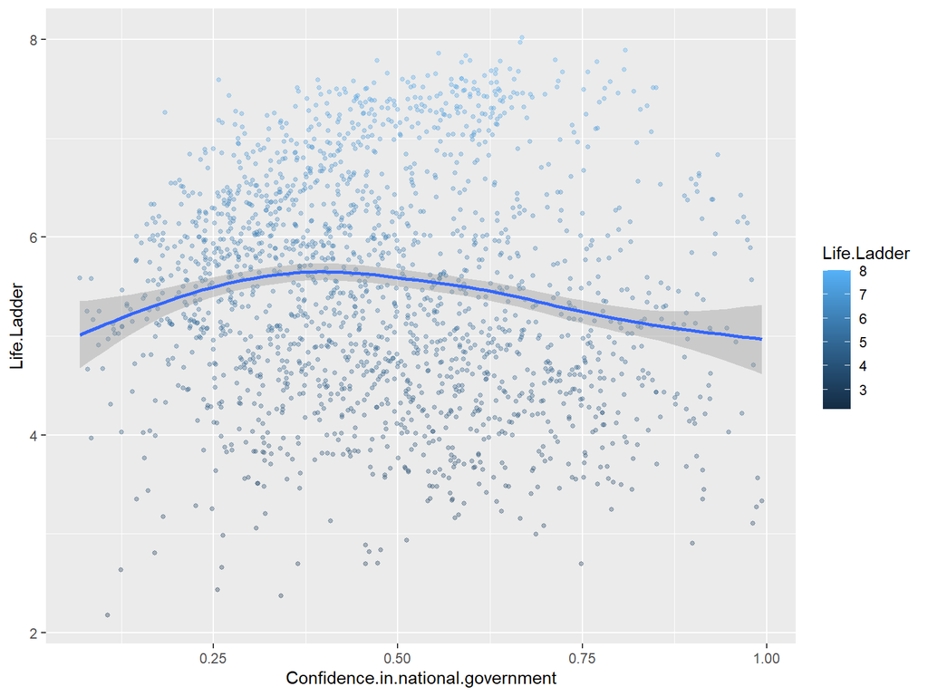

- This chart is overplotted and it is difficult to see a clear relationship.
- Let’s filter the data to make it more clear.

# This data is filtered to year 2021 and shows the countries with the highest confidence in the national government.

```
##    Country.Name Life.Ladder Confidence.in.national.government Year
## 1    Uzbekistan    6.185308                         0.9126734 2021
## 2     Singapore    6.586717                         0.8976218 2021
## 3      Tanzania    3.680568                         0.8913909 2021
## 4     Indonesia    5.433173                         0.8403391 2021
## 5   Switzerland    7.327672                         0.8378481 2021
## 6        Jordan    3.909149                         0.7911784 2021
## 7         India    3.558254                         0.7854754 2021
## 8        Norway    7.361574                         0.7735232 2021
## 9         Egypt    4.025748                         0.7640445 2021
## 10  Philippines    5.965058                         0.7632087 2021
## 11        Benin    4.493431                         0.7624159 2021
## 12 Sierra Leone    3.714294                         0.7530322 2021
```

## Here is a plot showing the relationship between high confidence in the Govt and happiness score

```
- There doesn't appear to be a relationship
```

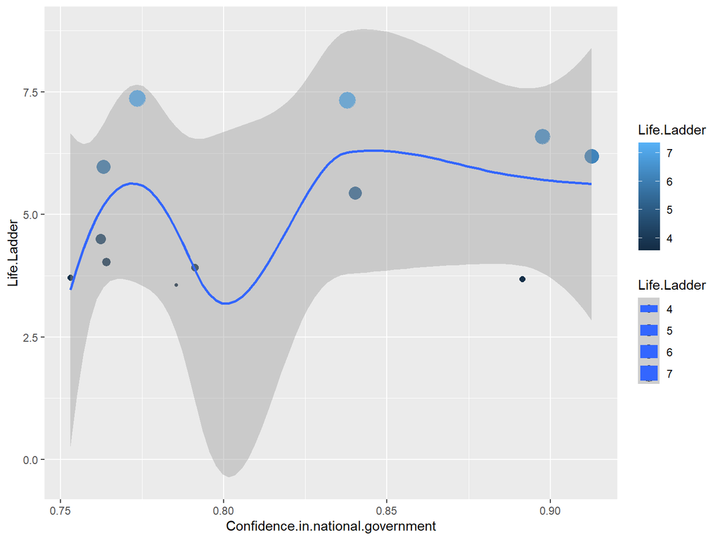

## Here is a plot showing the relationship between low confidence in the Govt and happiness score.

```
- The happiness score appears to be increasing as confidence increases.
```

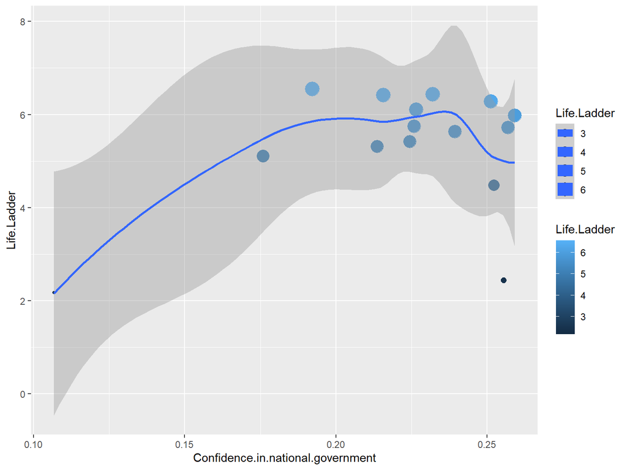

## Bolivia & USA

- I have heard that there is a high perception of corruption in Bolivia. I wanted to explore the relationship with a plot.

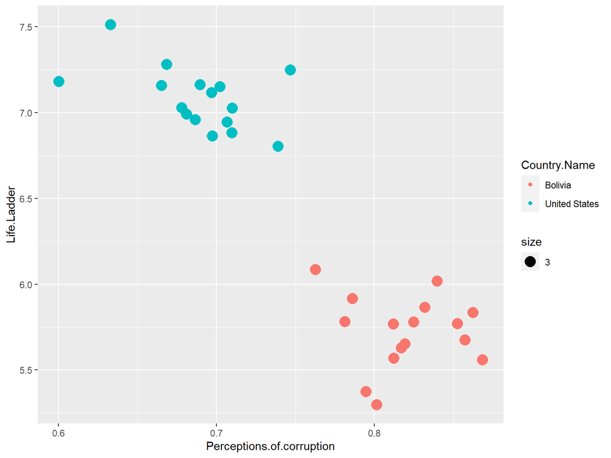

## Does healthy Life Expectancy have a relationship with Well-Being?

- Let’s explore the difference between Bolivia and the USA

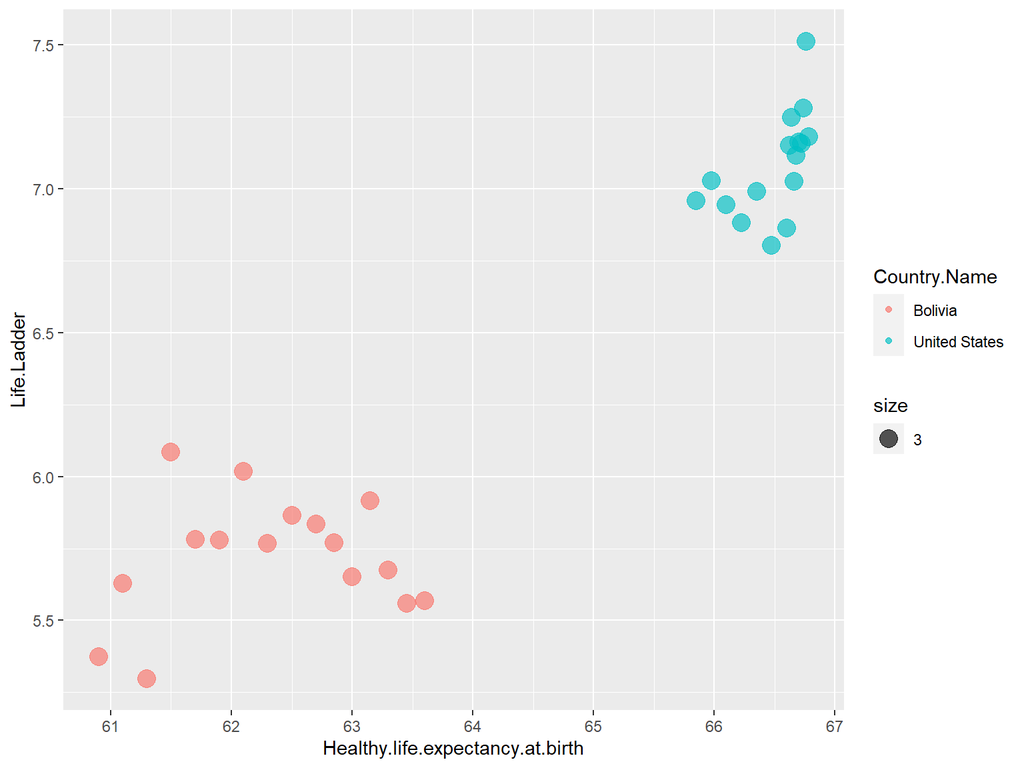

# The original dataset did not have a category for continent, however RStudio has a library called countrycode which can be used to categorize by continent.

- It uses the five continent model:

```r
##Five Continent Model

data1$Continent <- countrycode(sourcevar = data1$Country.Name,
                             origin = "country.name",
                             destination = "continent")

data1$Continent[data1$Country.Name == "Kosovo"] = "Europe"

by_continent = data1 %>% select(Country.Name,Continent, Life.Ladder) %>% arrange(Continent) %>% group_by(Continent)
```

## Continent DataFrame

- a dataframe showing the Life.Ladder for each continent
  - average
  - max
  - min

```
## # A tibble: 5 × 4
##   Continent   avg   max   min
##   <chr>     <dbl> <dbl> <dbl>
## 1 Africa     4.39  6.35  2.69
## 2 Americas   6.10  7.65  3.35
## 3 Asia       5.29  7.58  2.18
## 4 Europe     6.18  8.02  3.84
## 5 Oceania    7.28  7.60  7.11
```

## Because of the closeness in Oceania’s numbers, let’s take a closer look at Oceania to see which countries it represents in this dataset.

```r
Oceania =data1 %>% filter(Continent == 'Oceania') %>% count(Country.Name)
Oceania
```

```
##   Country.Name  n
## 1    Australia 15
## 2  New Zealand 15
```

- Now we know it only represents two countries.

## Average happiness score by Continent

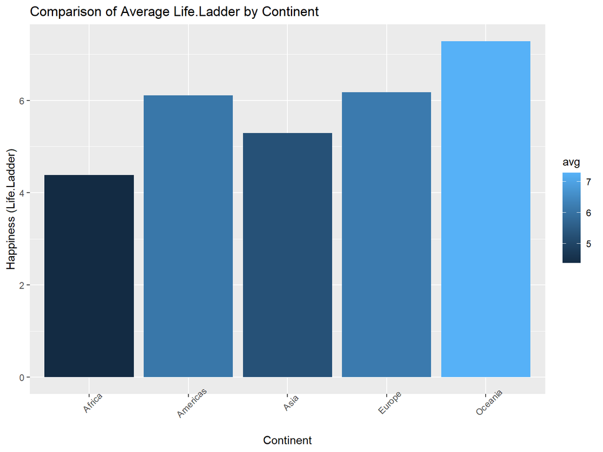

## Comparison of Max Life.Ladder score by Continent

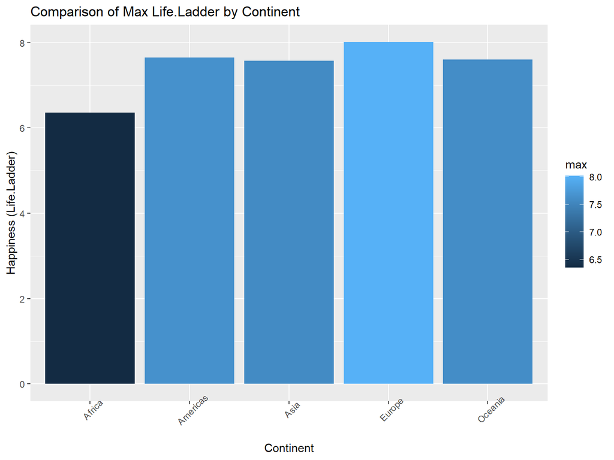

## Plot of Min Life.Ladder scores by Continent

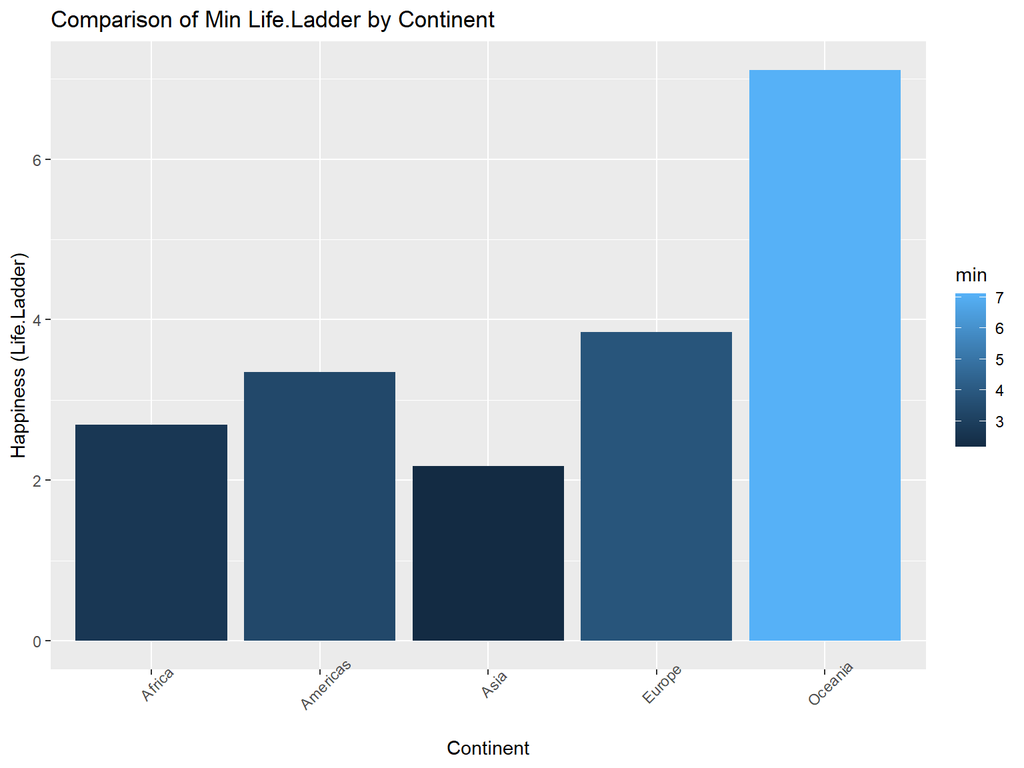

- Note that Oceania has only a small difference between the max and min.
- Oceania also has the fewest participants of all the continents.(Only 2 countries)

[output not shown]

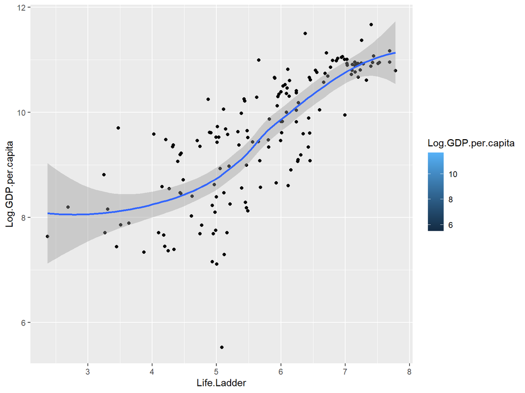

- According to the data, Life.Ladder generally increases with GDP.

# This dataframe shows the relationship between social support and the feeling of well-being.

[output not shown]

## A box plot of each Continent showing social support on the x-axis and life ladder on the y-axis

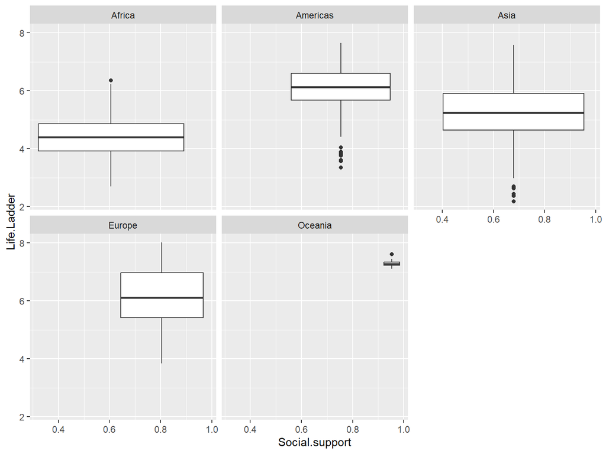